| Hazırlayan | Versiyon | Tarih | Dil |
| --- | --- | --- | --- |
| dataFLOYD | v1.01 | 12 Şub 2019 | TR |

# ConvNet nedir?

Tek bir cümleyle özetleyecek olursak, "Convolutional Neural Networks" (ConvNet) en çok kullanılan derin öğrenme mimarisidir.

ConvNet'ler yeterli ve kaliteli veri ile buluştuğu zaman bir çok problemde **"accuracy" değeri çok yüksek sonuçlar elde edilmesine** olanak sağlamaktadır.

> Günümüzde özellikle "computer vision" alanı ConvNet'ler ile çağ atlamıştır. Yani ConvNet'ler sayesinde bilgisayarlar insanlara yakın ve hatta insanlardan daha yüksek bir doğrulukla resimleri tanıyabilmekte, resimlerin içindeki nesneleri tespit edebilmekte ve daha birçok operasyonu gerçekleştirebilmektedir.

ConvNet mimarilerin atası sayılabilecek ilk mimariyi **Yann LeCun**'ın 1989 yılındaki ["Object Recognition with Gradient-Based Learning"](http://yann.lecun.com/exdb/publis/pdf/lecun-99.pdf) makalesinde görüyoruz. Daha sonra bu mimari biraz daha geliştirilerek 1998 yılında LeNet-5 halini almıştır. *Bu yöntemin o yıllarda karakter tanıma ile ilgili ticari ürünlerde de kullanıldığını belirtmekte fayda var.*

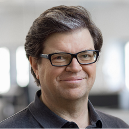

*Yann LeCun (AI Director of Facebook 2019)*

> Her ne kadar hatırı sayılır bir süredir bu metotlar biliniyor olsa da, bunların gerçek anlamda faydalı hale gelmesi GPU teknolojisinin gelişip çok daha derin mimarilerin büyük veriler üzerinde eğitilmesi sonucu olmuştur. ConvNet'ler ilk büyük zaferini 2012 yılında AlexNet mimarisinin, "ImageNet Large Scale Visual Recognition Challenge" yarışmasında rakiplerine fark atarak birinci olmasıyla elde etmişlerdir.

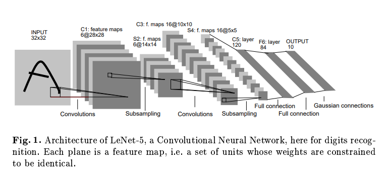

Yukarıdaki mimariyi biraz incelediğimizde temelde bir aşağıdaki adımların olduğunu görüyoruz:

1. Resim üzerindeki convolution operasyonları
2. Subsampling operasyonları
3. Full connection ve Gaussian Connection operasyonları

Bu aşamaların herbirine katman (layer) denilmektedir. Bu mimaride bahsedilenlerin dışında **max pooling**, **batch normalization** gibi birçok katman daha günümüzdeki mimarilerde kullanılmaktadır.

ConvNet katmanlardan oluşmuş bir yapıdır. Her katman 3 boyutlu bir girdiyi yine 3 boyutlu bir çıktıya dönüştürür.  
Bu yazımızda ConvNet'lerde kullanılan önemli katmanların aslında ne iş yaptığını inceleyeceğiz.

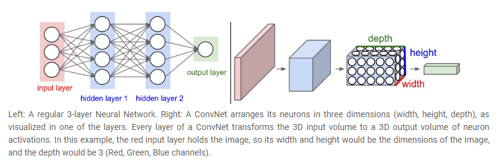

Ref: http://cs231n.github.io/convolutional-networks/

# Katmanlar

## Convolutional Layer

"Convolution" lafını her duyduğumda aklıma sayın hocam **Bülent Sankur** gelir. Kendisi sinyal dersinde bize bu kelimenin ne hangi etimolojik kökenden geldiğini anlatmıştı. Daha dün gibi hatılıyorum "Convolution" kelimesinin "Co-Evolution"dan geldiğini söylemişti, yani **birlikte evrim geçirmek**. Gerçekten de iki sinyalin geçirdiği transformasyonu çok güzel anlatan bir kelime olduğunu düşünmüştüm. Bunun Türkçe çevriminin de doğal olarak **"evrişim"** olduğunu belirtmişti.

> **Basitleştirilmiş tanım:** "Convolution" büyük bir resmin daha küçük bir resim ile çarpılıp toplanmasıdır. Bu çarpım ve toplama işlemi büyük resim üzerinde kaydırma yapılarak her adım için gerçekleştirilir.

**BONUS**  
Siz sevgili okurlarım için convolution olayını daha iyi anlatabilmek için aşağıdaki video'yu hazırladım. Faydalı olması dileğimle..

**Videodaki ana başlıklar**

- "Convolution" mekanizması nasıl çalışır?
- Adım adım "convolution" örneği
- Neden önemlidir?
- Önemli kavramlar
  - Filtre boyutu (Filter size)
  - Sıfır ekleme (Zero Padding)
  - Kaydırma (Stride)

```python
from IPython.display import YouTubeVideo
YouTubeVideo('33kTsvenLec',width=640,height=480)
```

[video not shown]

Yukarıdaki video umarım faydalı olmuştur. Bu tip videolardan daha çok hazırlamayı düşünüyorum önümüzdeki günlerde.

### Python'da "convolution" nasıl yapılır? Çıkan sonuçlar nasıl yorumlanır?

Bir resmi başka bir resim ile "convolve" yaptığımızda aslında bir filtreleme operasyonu gerçekleştiririz. **Yani küçük resimde bulunan şekillerin veya küçük resme benzeyen yapıların olduğu yerlerde "convolution" sonucu yüksek olur.** Şekillerin tam olarak benzemesine de gerek yoktur. Tam olarak benzerse sonuç çok yüksek biraz benzerse sonuç biraz daha düşük çıkar. Basit bir örnekle açıklayalım.

> "Convolution" renkli imgelere de uygulanabilir, fakat örneğin basit olması açısından burada siyah-beyaz imgeler (yani 2 boyutlu) üzerinde bir örnek yapalım

Elimizde paint programı yoluyla hazırlanmış 128x128'lik bir imge olsun. Bu imgenin içinde 3x3 piksel boyutlarında artılar mevcut

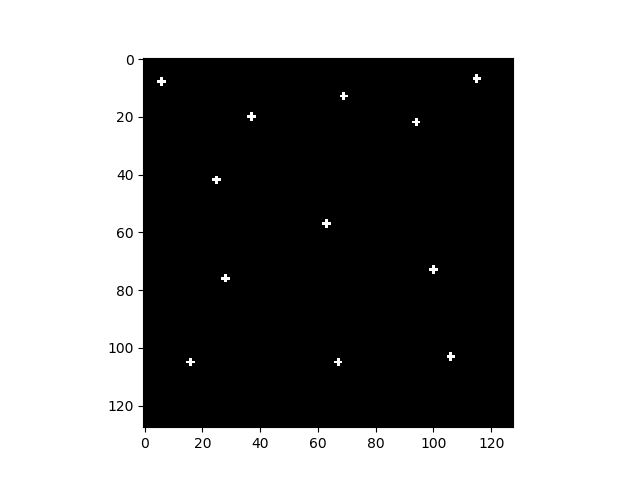

```python
%matplotlib notebook
# opencv modülünü yüklüyoruz
import cv2
import matplotlib.pyplot as plt
pluses = cv2.imread("pluses.bmp")
# siyah beyaza çevirelim
pluses = cv2.cvtColor(pluses,cv2.COLOR_BGR2GRAY)
plt.figure()
plt.imshow(pluses,cmap="gray")
```

> Yukarıdaki resimle "convolve" yapacağımız "kernel/filtre" (küçük resim) tek bir artıdan oluşsun. Yani 3x3 boyutlarında bir artıdan söz ediyorum.

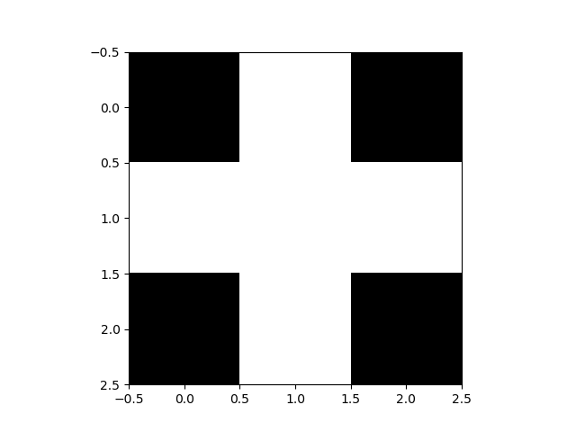

```python
single_plus = cv2.imread("single_plus.bmp")
# siyah beyaza çevirelim
single_plus = cv2.cvtColor(single_plus,cv2.COLOR_BGR2GRAY)
plt.figure()
plt.imshow(single_plus,cmap="gray")
```

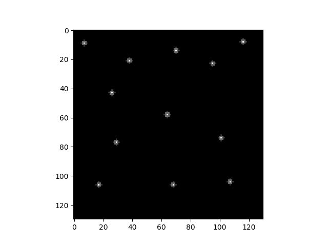

```python
# Convolution için scipy kütüphanesini kullanacağız
from scipy.signal import convolve2d
import numpy as np
out = convolve2d(pluses,single_plus,mode="full")
plt.figure()
plt.imshow(out,cmap="gray");
```

> Yukarıdaki "convolution" çıktısı olan resimde artıların olduğu noktalarda yüksek yoğunluklu bir beyazlık olduğunu görüyoruz. Yani bu çıktı ile ilk imgedeki artıların tam merkezlerini bulmak mümkün!

```python
locations = np.where([out == np.max(out)])
print("y koordinatları")
print(locations[1])
print("x koordinatları")
print(locations[2])
```

```
y koordinatları
[  8   9  14  21  23  43  58  74  77 104 106 106]
x koordinatları
[116   7  70  38  95  26  64 101  29 107  17  68]
```

### ConvNet'te filtreler neler öğreniyor?

ConvNet mimarilerinde bu "kernel" veya "filtre" dediğimiz yapılardan (örnekteki küçük artı) bir sürü var. İşin güzel tarafı bu filtrelerin katsayıları yani içerdikleri rakamlar yapay sinir ağının eğitimi sırasında otomatik olarak belirleniyorlar. Yani eğitim için kullandığınız veri setindeki temel yapıları öğreniyorlar!

Örneğin aşağıdaki makalede bir convnet'in öğrendiği filtreleri örneklendirmişler. Buradaki filtrelerin ve genellikle derin öğrenmede kulllanılan filtrelerin üç boyutlu olduğunu belirtmekte fayda var.

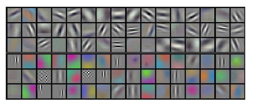

[ImageNet Classification with Deep Convolutional Neural Networks](https://papers.nips.cc/paper/4824-imagenet-classification-with-deep-convolutional-neural-networks.pdf)

## Pooling Layer

Şimdi "convolution"dan çıktığımıza göre bir sıradaki katmanımız "pooling layer"ı inceleyelim.

"Pooling" katmanı "convolution"a çok benzer. Bu operasyonda da yine belirli bir büyüklüğe sahip filtremiz vardır ve bu filtreyi büyük resmin üzerinde dolaştırırız.

Yapılan işlem ise filtrenin gezdiği yerlerde çarpma ve toplama işlemi yapmak yerine, buradan büyük resme ait tek bir sayıyı seçmektir. Bu sayıyı nasıl seçtiğimiz filtrenin tipini belirler. Örneğin:

- Eğer en büyük sayı seçiliyorsa "max pooling"
- Sayıların ortalamaları alınıyorsa "average pooling" katmanı kullanılıyor deriz

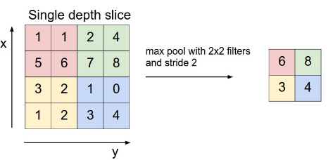

## Activation Layer

Belli başlı kullanılan aktivasyon fonksiyonlarını sayacak olursak:

### ReLU (Rectified Linear Unit)

En çok kullanılan aktivasyon fonksiyonudur. Ne yapacağınızı bilmiyorsanız bunu kullanın :) Sıfırdan büyük sayılar için lineer davranır, sıfırdan küçük sayılar için 0'dır.

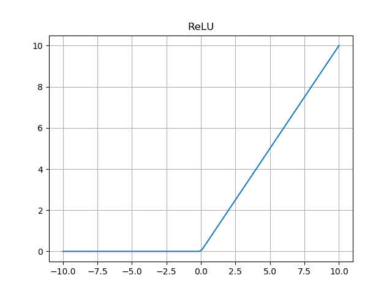

```python
import numpy as np
import matplotlib.pyplot as plt
def relu(x):
    out = np.zeros(len(x))
    out[x>0] = x[x>0]
    return out

x = np.linspace(-10,10,100)
y = relu(x)


plt.figure()
plt.plot(x,y)
plt.grid()
plt.title("ReLU")
plt.show()
```

### Sigmoid

Bunu belki logistic regression'dan hatırlarsınız. Yaptığı şey girdiyi 0 ile 1 arasına sıkıştırmaktır. Çok büyük değerler yani yaklaşık 5'ten sonra çıktı olarak 1 verir. Aşağıdaki gibi bir fonksiyona sahiptir.

\begin{equation*} f(x)=\frac{1}{1+e^{-x}} \end{equation*}

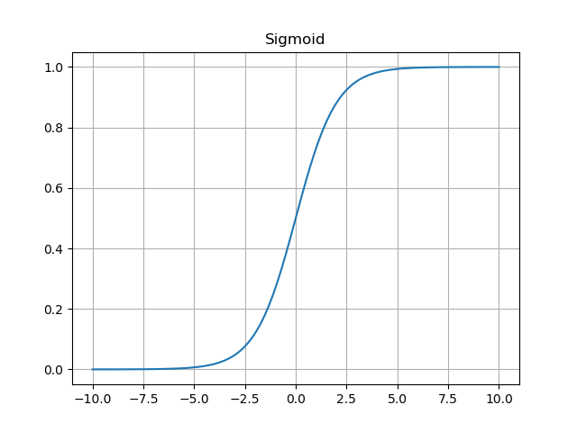

```python
def sigmoid(x):
    # ilk denklem
    out = 1 / (1 + np.exp(-x))

    return out

x = np.linspace(-10,10,100)
y = sigmoid(x)


plt.figure()
plt.plot(x,y)
plt.grid()
plt.title("Sigmoid")
plt.show()
```

Bu fonksiyon geçmişte çok kullanılmıştır. Çünkü karakteristiği fiziksel bir nöronun ateşlenmesine çok benzemektedir.

**Fakat sigmoid fonksiyonu çok tercih edilmez.** Çünkü sinir ağlarının eğitimi sırasında gradyanların kaybolmasına sebep olur, bir başka deyişle yapay sinir ağları kısa bir sürede öğrenemez hale gelir. Kullanılmamasının ikinci bir sebebi de bu fonksiyonun 0 etrafında simetrik olmamasıdır.

### Tanh

Sigmoid'in 0 etrafında simetrik hale getirilmesi ile oluşur. Sigmoid'e göre simetrik olması nedeniyle daha iyidir ama bu da çok tercih edilen bir fonksiyon değildir.

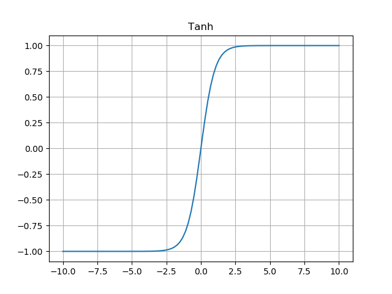

```python
def tanh(x):
    # ilk denklem
    out = 2*sigmoid(2*x) - 1

    return out

x = np.linspace(-10,10,100)
y = tanh(x)


plt.figure()
plt.plot(x,y)
plt.grid()
plt.title("Tanh")
plt.show()
```

### Leaky ReLU

ReLU'nun çok avantajlı olduğunu söylemiştik. Tekrar edecek olursak:

- Sigmoid ve Tanh'deki exp operasyonlarına karşılık ReLU'da sadece kıyaslama kullanılır bu sebeple çok hızlıdır
- Sigmoid ve Tanh'ye kıyasla yapay sinir ağının çok hızlı yakınsayıp, kısa sürede yüksek performans değerleri elde etmesini sağlar.

Ne yazık ki ReLU'nun da bazı dezavantajarı vardır. Bunlardan en başta geleni; nöronun eğitim sırasında ölmesine sebep olmasıdır. Ölen nöron eğitim boyunca bir daha aktive olmaz. Öğrenme hızı yüksek yapıldığında genellikle bu fenomenle karılaşılmaktadır.

ReLu'nun bu dezavantajını gidermek için negatif değerlerde 0 yerine çok küçük değer alan "Leaky Relu" önerilmektedir.

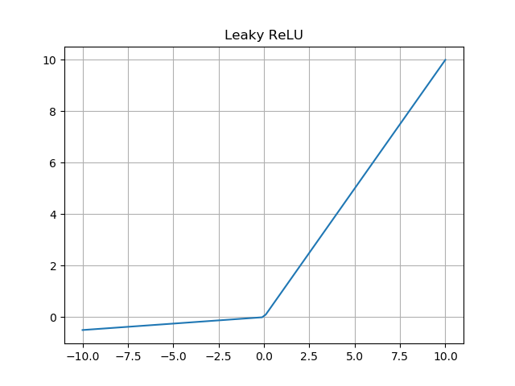

```python
def leaky_relu(x,alpha=0.05):
    out = np.zeros(len(x))
    out[x>0] = x[x>0]
    out[x<=0] = x[x<=0]*alpha
    return out

x = np.linspace(-10,10,100)
y = leaky_relu(x)


plt.figure()
plt.plot(x,y)
plt.grid()
plt.title("Leaky ReLU")
plt.show()
```

Literatürde bu yöntemin başarılı olduğuna dair bir fikir birliği yoktur. [*](http://cs231n.github.io/neural-networks-1/)

### Maxout

Ian Goodfellow tarafından önerilmiş bir [yöntemdir](https://arxiv.org/pdf/1302.4389.pdf). Şu fonksiyonu kullanır: $$\max(w_1^Tx+b_1, w_2^Tx + b_2)$$ Bu yöntemde aktivasyon fonksiyonu da $w_1,b_1,w_2,b_2$ parametreleri vasıtası ile öğrenilmektedir. Ne yazık ki bu yöntem katman başına parametrelerin ikiye katlanmasına sebep olmaktadır.

## Flatten Layer

Bu katman kendine gelen girdiyi tek boyutlu bir hale indirger. Yani diyelim ki (64,64,3) boyutunda bir imgemiz var. Bunu "flatten" yaptığımız zaman 64*64*3 = 12288x1 boyutunda bir vektör elde ederiz.

Genellikle "Fully Connected" katmandan önce kullanılır.

## Fully Connected Layer

Bir önceki katmana tümüyle bağlanan nöronlardan oluşur. Klasik bir yapay sinir ağını anlatmaktadır.

## Normalization Layer

İstatistiksel normalizasyon en basit haliyle bir veriyi ortalaması 0 ve varyansı 1 haline getirmek olarak tanımlanabilir.

Derin öğrenme mimarilerinde "batch normalization" genellikle bir katmandan hemen sonra aktivasyon fonksiyonu çağrılmadan önce kullanılır. Buradaki amaç çıktıları normalize ederek regularizasyon sağlamak ve yapay sinir ağının "overfit" yapmasını engellemektir.

Batch Normalization ile ilgili en önemli makale aşağıdaki bağlantıdadır:  
[Batch Normalization: Accelerating Deep Network Training by Reducing Internal Covariate Shift](https://arxiv.org/abs/1502.03167)

## Dropout Layer

Bu katman eğitim sırasında her iterasyonda belirli oranda nöronun rastgele kapatılmasını sağlar. Ayrıntısına girmeden bunun da önemli bir regülarizasyon tekniği olduğunu söyleyebiliriz. Aşağıdaki örnekte dropout değeri 0.5 olan katmanın her seferinde farklı nöronlarının aktive olduğunu görebiliriz.

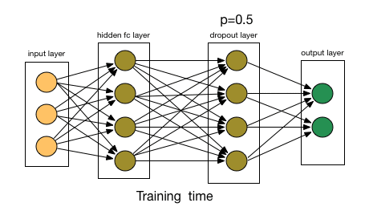

[Reference](https://www.analyticsvidhya.com/blog/2018/04/fundamentals-deep-learning-regularization-techniques/)

Bu konuda en önemli makale Dropout Paper olarak da bilinir, daha fazla bilgi için bakabilirsiniz:  
http://www.cs.toronto.edu/~rsalakhu/papers/srivastava14a.pdf

# Bir ConvNet Örneği - VGGNet

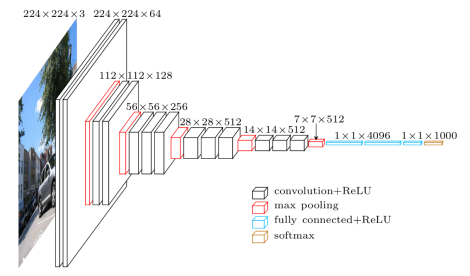

Şimdi VGG'yi yükleyelim ve katmanlarına bakalım.

```python
import keras
vgg = keras.applications.vgg16.VGG16()
print(vgg.summary())
```

```
_________________________________________________________________
Layer (type)                 Output Shape              Param #
=================================================================
input_1 (InputLayer)         (None, 224, 224, 3)       0
_________________________________________________________________
block1_conv1 (Conv2D)        (None, 224, 224, 64)      1792
_________________________________________________________________
block1_conv2 (Conv2D)        (None, 224, 224, 64)      36928
_________________________________________________________________
block1_pool (MaxPooling2D)   (None, 112, 112, 64)      0
_________________________________________________________________
block2_conv1 (Conv2D)        (None, 112, 112, 128)     73856
_________________________________________________________________
block2_conv2 (Conv2D)        (None, 112, 112, 128)     147584
_________________________________________________________________
block2_pool (MaxPooling2D)   (None, 56, 56, 128)       0
_________________________________________________________________
block3_conv1 (Conv2D)        (None, 56, 56, 256)       295168
_________________________________________________________________
block3_conv2 (Conv2D)        (None, 56, 56, 256)       590080
_________________________________________________________________
block3_conv3 (Conv2D)        (None, 56, 56, 256)       590080
_________________________________________________________________
block3_pool (MaxPooling2D)   (None, 28, 28, 256)       0
_________________________________________________________________
block4_conv1 (Conv2D)        (None, 28, 28, 512)       1180160
_________________________________________________________________
block4_conv2 (Conv2D)        (None, 28, 28, 512)       2359808
_________________________________________________________________
block4_conv3 (Conv2D)        (None, 28, 28, 512)       2359808
_________________________________________________________________
block4_pool (MaxPooling2D)   (None, 14, 14, 512)       0
_________________________________________________________________
block5_conv1 (Conv2D)        (None, 14, 14, 512)       2359808
_________________________________________________________________
block5_conv2 (Conv2D)        (None, 14, 14, 512)       2359808
_________________________________________________________________
block5_conv3 (Conv2D)        (None, 14, 14, 512)       2359808
_________________________________________________________________
block5_pool (MaxPooling2D)   (None, 7, 7, 512)         0
_________________________________________________________________
flatten (Flatten)            (None, 25088)             0
_________________________________________________________________
fc1 (Dense)                  (None, 4096)              102764544
_________________________________________________________________
fc2 (Dense)                  (None, 4096)              16781312
_________________________________________________________________
predictions (Dense)          (None, 1000)              4097000
=================================================================
Total params: 138,357,544
Trainable params: 138,357,544
Non-trainable params: 0
_________________________________________________________________
None
```

VGG'nin belli başlı özelliklerini saymak gerekirse:

- VGG'de her bir convolution adımı 3x3 matrislerden oluşmaktadır.
- Girdi imgelerine 1 piksel "pad" yapılmıştır. Böylece 3x3 bir matris ile "convolve" edildiği zaman yine aynı boyutta bir çıktı elde ediyoruz.
- "Stride" parametresi ise 1 olarak belirlenmiştir.
- Max Pooling katmanlar ise 2x2 ve "stride" değeri ise 2 olarak tanımlanmıştır.

Bu teorik bilgilerimizi, yüklediğimiz modeli inceleyerek doğrulamaya çalışalım:

```python
# Keras'ta bir modelin katmanlarını analiz etmek için layers metodu kullanılır
# Bu metod indekslenebilir.
# Örneğin ilk katmanın konfigürasyonunu bulalım
vgg.layers[0].get_config()
```

```
{'batch_input_shape': (None, 224, 224, 3),
 'dtype': 'float32',
 'sparse': False,
 'name': 'input_1'}
```

```python
# Şimdi ilk convolution katmanının
# konfigürasyonuna bakalım
vgg.layers[1].get_config()
```

```
{'name': 'block1_conv1',
 'trainable': True,
 'filters': 64,
 'kernel_size': (3, 3),
 'strides': (1, 1),
 'padding': 'same',
 'data_format': 'channels_last',
 'dilation_rate': (1, 1),
 'activation': 'relu',
 'use_bias': True,
 'kernel_initializer': {'class_name': 'VarianceScaling',
  'config': {'scale': 1.0,
   'mode': 'fan_avg',
   'distribution': 'uniform',
   'seed': None}},
 'bias_initializer': {'class_name': 'Zeros', 'config': {}},
 'kernel_regularizer': None,
 'bias_regularizer': None,
 'activity_regularizer': None,
 'kernel_constraint': None,
 'bias_constraint': None}
```

Gördüğünüz gibi ilk "convolutional layer"daki parametreleri kolaylıkla elde ettik. Yukarıda konuştuğumuz temel "convolution" kavramlarını hatırlayalım ve buradaki karşılıklarına bakalım:

## İlk katmandaki filtrelerin görselleştirilmesi

> Bu ilk katmandaki filtreleri görselleştirebilir miyiz acaba? Bunun için ilk katmandaki "weigth"leri yani filrelerin katsayılarını almamız lazım.

```python
weights = vgg.layers[1].get_weights()
print(weights[0].shape)
```

```
(3, 3, 3, 64)
```

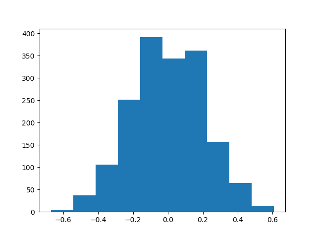

```python
# 64 adet filtre olduğunu görüyoruz. Bunların her birinin boyutu 3x3x3. Sonundaki 3 katsayısı R,G,B kanalllarını belirtiyor.
# İlk önce değerler nasıl dağılmış bir bakalım
plt.figure()
# Tüm ağırlıkları alıp çizdirelim
plt.hist(np.ndarray.flatten(weights[0]))
plt.show()
```

Buradaki rakamları 0-255 arasında göndermeliyiz ki imge halinde görebilelim. *François Chollet Bey*'in önerdiği fonksiyonu kullanalım.

```python
# https://blog.keras.io/how-convolutional-neural-networks-see-the-world.html
def deprocess_image(x):
    # normalize tensor: center on 0., ensure std is 0.1
    x -= x.mean()
    x /= (x.std() + 1e-5)
    x *= 0.1

    # clip to [0, 1]
    x += 0.5
    x = np.clip(x, 0, 1)

    # convert to RGB array
    x *= 255
    x = x.transpose((1, 2, 0))
    x = np.clip(x, 0, 255).astype('uint8')
    return x
```

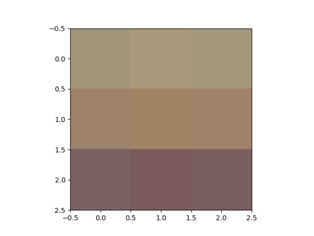

```python
processed = deprocess_image(weights[0][:,:,:,0])
plt.figure()
plt.imshow(processed)
plt.show()
```

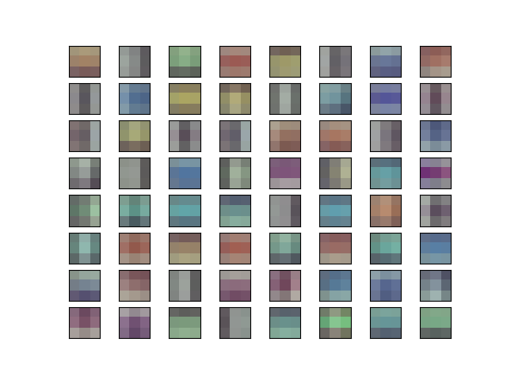

```python
# Şimdi 64 adet filtrenin hepsini birden gösterelim isterseniz
plt.figure()
for i in range(64):
    ax = plt.subplot(8,8,i+1)
    processed = deprocess_image(weights[0][:,:,:,i])
    plt.imshow(processed)
    ax.set_xticks([])
    ax.set_yticks([])
plt.show()
```

Buraya kadar okuduğunuz için çok teşekkürler. Bir başka yazıda görüşmek üzere, esen kalın!